# Report

I randomly selected two indices from the test dataset. The indices were 28 and 38.

## Random Forrest

I used radom forest as tree based model.

Probailty of heart attack for patient 28 equals: 55.38228180752807%  
Probailty of heart attack for patient 38 equals: 23.03908323870259%

[figure not shown]

One can see that for patient 28 the *thalachh* feature has positive shapley values and for patient 38 has negative. This kind of situations happen when different values of some input goes with different results of classification. For example if one person has low salary it implies that the person is not wealthy on the other hand high salary suggest that the person is wealathy.

[figure not shown]

In this method (shap library) results are the same as in dalex library. I guess that for many features in the dataset there might be some differences between those libraries depending on the method of the estimation. Probably for explaining neural networks working on image input both metods may show different results.

## SVM

Probailty of heart attack for patient 28 equals: 32.8056375699065%  
Probailty of heart attack for patient 38 equals: 39.61395034409673%

[figure not shown]

Method SVM with rbf kernel works differentelly than decision trees. This causes different learning process, different classification conditions and different results. Probability scores calculated by two methods for patient 28 are extremly different. This also refers to shap values. Different features have main impact on the final output and that is why shaple values may differ. Many features are both negative or both positive for both methods which means that sometimes models work similarly but on the other hand for SVM second most important feature for patient 38 is *restecg2* which not apperas in top 9 impacing features of random forest.

# Appendix

```python
pip install dalex shap
```

```python
import pandas as pd
from sklearn.model_selection import train_test_split
from sklearn.ensemble import RandomForestClassifier, RandomForestRegressor
from sklearn.svm import SVC, SVR
from sklearn.linear_model import LogisticRegression, LinearRegression
import dalex as dx
import shap
import random
```

```python
hearts_df = pd.read_csv("heart.csv")
```

```python
hearts_df.info()
```

```
<class 'pandas.core.frame.DataFrame'>
RangeIndex: 303 entries, 0 to 302
Data columns (total 14 columns):
 #   Column    Non-Null Count  Dtype
---  ------    --------------  -----
 0   age       303 non-null    int64
 1   sex       303 non-null    int64
 2   cp        303 non-null    int64
 3   trtbps    303 non-null    int64
 4   chol      303 non-null    int64
 5   fbs       303 non-null    int64
 6   restecg   303 non-null    int64
 7   thalachh  303 non-null    int64
 8   exng      303 non-null    int64
 9   oldpeak   303 non-null    float64
 10  slp       303 non-null    int64
 11  caa       303 non-null    int64
 12  thall     303 non-null    int64
 13  output    303 non-null    int64
dtypes: float64(1), int64(13)
memory usage: 33.3 KB
```

Data is complete and all columns are numeric.

```python
for i in range(4):
  hearts_df[f"cp{i}"] = (hearts_df["cp"] == i) * 1
for i in range(3):
  hearts_df[f"restecg{i}"] = (hearts_df["restecg"] == i) * 1
```

```python
y_heart = hearts_df["output"]
x_heart = hearts_df.drop(columns=["cp", "restecg", "output"])
```

```python
x_heart.describe()
```

|  | age | sex | trtbps | chol | fbs | thalachh | exng | oldpeak | slp | caa | thall | cp0 | cp1 | cp2 | cp3 | restecg0 | restecg1 | restecg2 |
| --- | --- | --- | --- | --- | --- | --- | --- | --- | --- | --- | --- | --- | --- | --- | --- | --- | --- | --- |
| count | 303.000000 | 303.000000 | 303.000000 | 303.000000 | 303.000000 | 303.000000 | 303.000000 | 303.000000 | 303.000000 | 303.000000 | 303.000000 | 303.000000 | 303.000000 | 303.000000 | 303.000000 | 303.000000 | 303.000000 | 303.000000 |
| mean | 54.366337 | 0.683168 | 131.623762 | 246.264026 | 0.148515 | 149.646865 | 0.326733 | 1.039604 | 1.399340 | 0.729373 | 2.313531 | 0.471947 | 0.165017 | 0.287129 | 0.075908 | 0.485149 | 0.501650 | 0.013201 |
| std | 9.082101 | 0.466011 | 17.538143 | 51.830751 | 0.356198 | 22.905161 | 0.469794 | 1.161075 | 0.616226 | 1.022606 | 0.612277 | 0.500038 | 0.371809 | 0.453171 | 0.265288 | 0.500606 | 0.500824 | 0.114325 |
| min | 29.000000 | 0.000000 | 94.000000 | 126.000000 | 0.000000 | 71.000000 | 0.000000 | 0.000000 | 0.000000 | 0.000000 | 0.000000 | 0.000000 | 0.000000 | 0.000000 | 0.000000 | 0.000000 | 0.000000 | 0.000000 |
| 25% | 47.500000 | 0.000000 | 120.000000 | 211.000000 | 0.000000 | 133.500000 | 0.000000 | 0.000000 | 1.000000 | 0.000000 | 2.000000 | 0.000000 | 0.000000 | 0.000000 | 0.000000 | 0.000000 | 0.000000 | 0.000000 |
| 50% | 55.000000 | 1.000000 | 130.000000 | 240.000000 | 0.000000 | 153.000000 | 0.000000 | 0.800000 | 1.000000 | 0.000000 | 2.000000 | 0.000000 | 0.000000 | 0.000000 | 0.000000 | 0.000000 | 1.000000 | 0.000000 |
| 75% | 61.000000 | 1.000000 | 140.000000 | 274.500000 | 0.000000 | 166.000000 | 1.000000 | 1.600000 | 2.000000 | 1.000000 | 3.000000 | 1.000000 | 0.000000 | 1.000000 | 0.000000 | 1.000000 | 1.000000 | 0.000000 |
| max | 77.000000 | 1.000000 | 200.000000 | 564.000000 | 1.000000 | 202.000000 | 1.000000 | 6.200000 | 2.000000 | 4.000000 | 3.000000 | 1.000000 | 1.000000 | 1.000000 | 1.000000 | 1.000000 | 1.000000 | 1.000000 |

```python
for column in x_heart.columns:
  x_heart[column] = (x_heart[column] - x_heart[column].mean()) / x_heart[column].std()
```

```python
X_train_heart, X_test_heart, y_train_heart, y_test_heart = train_test_split(x_heart, y_heart, test_size=0.33, random_state=446519)
```

```python
rf_h = RandomForestClassifier(n_estimators = 300, max_depth=5, random_state=446519)
rf_h.fit(X_train_heart, y_train_heart)
```

```
RandomForestClassifier(max_depth=5, n_estimators=300, random_state=446519)
```

```python
random.seed(446519)

idx1 = random.randint(0, X_test_heart.shape[0] - 1)
idx2 = random.randint(0, X_test_heart.shape[0] - 1)
```

```python
sample1 = X_test_heart.iloc[[idx1]]
sample2 = X_test_heart.iloc[[idx2]]
```

```python
print(f"Probailty of heart attack in first sample equals: {rf_h.predict_proba(sample1)[0][1]*100}%")
print(f"Probailty of heart attack in second sample equals: {rf_h.predict_proba(sample2)[0][1]*100}%")
```

```
Probailty of heart attack in first sample equals: 55.38228180752807%
Probailty of heart attack in second sample equals: 23.03908323870259%
```

```python
model_predicting_method = lambda m, d: m.predict_proba(d)[:, 1]

explainer_dx_rf_a = dx.Explainer(rf_h, X_test_heart, y_test_heart, predict_function=model_predicting_method, label="RF_heart_attack")
```

```
Preparation of a new explainer is initiated

  -> data              : 100 rows 18 cols
  -> target variable   : Parameter 'y' was a pandas.Series. Converted to a numpy.ndarray.
  -> target variable   : 100 values
  -> model_class       : sklearn.ensemble._forest.RandomForestClassifier (default)
  -> label             : RF_heart_attack
  -> predict function  : <function <lambda> at 0x0000020C6BF3A820> will be used
  -> predict function  : Accepts pandas.DataFrame and numpy.ndarray.
  -> predicted values  : min = 0.0096, mean = 0.517, max = 0.972
  -> model type        : classification will be used (default)
  -> residual function : difference between y and yhat (default)
  -> residuals         : min = -0.866, mean = 0.0334, max = 0.948
  -> model_info        : package sklearn

A new explainer has been created!
```

```python
explainer_dx_rf_a.model_performance()
```

|  | recall | precision | f1 | accuracy | auc |
| --- | --- | --- | --- | --- | --- |
| RF_heart_attack | 0.854545 | 0.854545 | 0.854545 | 0.84 | 0.896566 |

```python
shap_attributions_rf = [explainer_dx_rf_a.predict_parts(X_test_heart.iloc[[i]], type="shap", label=f'patient {i}') for i in [idx1, idx2]]
```

```python
shap_attributions_rf[0].plot(shap_attributions_rf[1::])
```

[interactive chart not shown]

```python
rf_predicting_method = lambda d: rf_h.predict_proba(d)[:, 1]
explainer_shap_rf_a = shap.Explainer(rf_predicting_method, X_test_heart)
```

```python
shap_values = explainer_shap_rf_a(X_test_heart.iloc[[idx1, idx2]])
```

```python
shap_values
```

[output not shown]

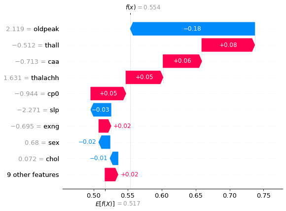

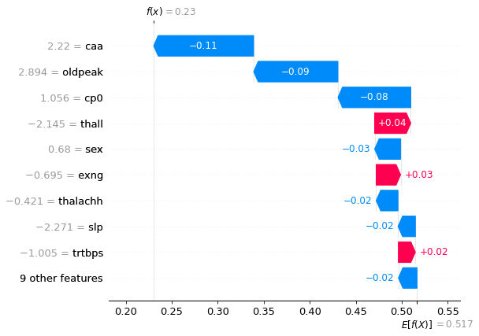

```python
for i in range(0,2):
  shap.plots.waterfall(shap_values[i])
```

```python
svc_h = SVC(random_state=446519, probability=True)
svc_h.fit(X_train_heart, y_train_heart)
```

```
SVC(probability=True, random_state=446519)
```

```python
print(f"Probailty of heart attack in first sample equals: {svc_h.predict_proba(sample1)[0][1]*100}%")
print(f"Probailty of heart attack in second sample equals: {svc_h.predict_proba(sample2)[0][1]*100}%")
```

```
Probailty of heart attack in first sample equals: 32.805637569906466%
Probailty of heart attack in second sample equals: 39.613950344096615%
```

```python
explainer_dx_svc_a = dx.Explainer(svc_h, X_test_heart, y_test_heart, predict_function=model_predicting_method, label="RF_heart_attack")
```

```
Preparation of a new explainer is initiated

  -> data              : 100 rows 18 cols
  -> target variable   : Parameter 'y' was a pandas.Series. Converted to a numpy.ndarray.
  -> target variable   : 100 values
  -> model_class       : sklearn.svm._classes.SVC (default)
  -> label             : RF_heart_attack
  -> predict function  : <function <lambda> at 0x0000020C6BF3A820> will be used
  -> predict function  : Accepts pandas.DataFrame and numpy.ndarray.
  -> predicted values  : min = 0.00806, mean = 0.515, max = 0.97
  -> model type        : classification will be used (default)
  -> residual function : difference between y and yhat (default)
  -> residuals         : min = -0.898, mean = 0.035, max = 0.984
  -> model_info        : package sklearn

A new explainer has been created!
```

```python
shap_attributions_svc = [explainer_dx_svc_a.predict_parts(X_test_heart.iloc[[i]], type="shap", label=f'patient {i}') for i in [idx1, idx2]]
shap_attributions_svc[0].plot(shap_attributions_svc[1::])
```

[interactive chart not shown]

# Task B

```
v() = 0
v(A) = 20
v(B) = 20
v(C) = 60
v(A,B) = 60
v(A,C) = 70
v(B,C) = 70
v(A,B,C) = 100
```

```python
v = {
     "0": 0,
     "0A": 20,
     "0B": 20,
     "0C": 60,
     "0AB": 60,
     "0AC": 70,
     "0BC": 70,
     "0ABC": 100
}
```

```python
import numpy as np
```

```python
def factorial(x: int) -> int:
  result = 1
  for i in range(2, x+1):
    result *= i

  return result


def get_shapley_value_for_player(player: str, values: dict, nub_players: int) -> float:
  score = 0.0
  for key, value in values.items():
    if player in key:
      score += (value - values[key.replace(player, "")]) / ((len(key) - 1) * factorial(nub_players) / factorial(len(key) - 1) / factorial(nub_players - (len(key) - 1)))

  return score
```

```python
get_shapley_value_for_player("A", v, 3)
```

```
25.0
```

```python
get_shapley_value_for_player("B", v, 3)
```

```
25.0
```

```python
get_shapley_value_for_player("C", v, 3)
```

```
50.00000000000001
```